# Seidr ROC curves

2025-04-08

# 1 Setup

- Libraries

```r
suppressPackageStartupMessages({
  library(gplots)
  library(here)
  library(matrixStats)
  library(pander)
  library(tidyverse)
})
```

- Colors

```r
hpal <- colorRampPalette(c("blue","white","red"))(100)
```

- Functions

```r
plotRoc <- function(f){

  dat <- read_tsv(f,
           col_names = c("TP","FP","PR","ALGORITHM"),
           col_types = cols(.default=col_double(),
                            ALGORITHM = col_character()),
           comment="#")

  vals <- read_lines(f) %>% subset(grepl("#",.))
  lvals <- length(vals)/3
  tabs <- tibble(ALGO=sapply(strsplit(vals[lvals + seq(1,length.out=lvals,by=2)],"\t"),"[",2),
         TP=as.integer(sapply(strsplit(vals[1:lvals],"\t"),"[",2)),
         FP=as.integer(sapply(strsplit(vals[1:lvals],"\t"),"[",3)),
         AUC=as.double(sub(".* ","",sapply(strsplit(vals[lvals + seq(1,length.out=lvals,by=2)],"\t"),"[",1))),
         AUPR=as.double(sub(".* ","",sapply(strsplit(vals[lvals + seq(2,length.out=lvals,by=2)],"\t"),"[",1))),
         )

  # we used to calc the AUC before seidr did it, so that's left in as
  # an example how to use trapz
  # require(pracma)
  # aucs <- dat %>% group_by(ALGORITHM) %>%
  #   group_map(.,function(x,...){data.frame(ALGORITHM=unique(x$ALGORITHM),
  #                                          AUC=round(trapz(x$FP,x$TP),digits=3))},
  #             .keep=TRUE) %>% bind_rows()
  #
  p <- ggplot(dat,aes(x=FP,y=TP,col=ALGORITHM,group=ALGORITHM)) +
    geom_line() +
    scale_x_continuous(name="1-specificity (FPR)") +
    scale_y_continuous(name="sensitivity (TPR)") +
    ggtitle(label=paste(sub("_roc\\.tsv","",basename(f)), " ROC curve"))

  suppressMessages(suppressWarnings(plot(p)))

  return(tabs)

}
```

# 2 ROC

## 2.1 Aggregated

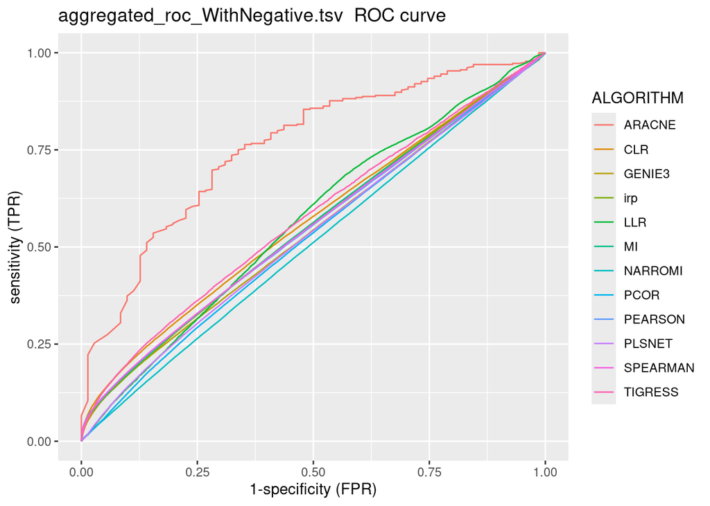

```r
res <- plotRoc(here("data/seidr/results/ResRoc/aggregated_roc_WithNegative.tsv"))
```

### 2.1.1 Stats of the gold standard analysis

```r
pander(res)
```

| ALGO | TP | FP | AUC | AUPR |
| --- | --- | --- | --- | --- |
| ARACNE | 364 | 71 | 0.7574 | 0.02513 |
| CLR | 133121 | 121272 | 0.5665 | 0.001317 |
| GENIE3 | 150917 | 151842 | 0.5404 | 0.001046 |
| LLR | 102155 | 95525 | 0.5649 | 0.0006462 |
| MI | 243030 | 247393 | 0.5514 | 0.001279 |
| NARROMI | 183602 | 206296 | 0.5088 | 0.0006217 |
| PCOR | 243030 | 247393 | 0.5266 | 0.0005456 |
| PEARSON | 243030 | 247393 | 0.5499 | 0.001563 |
| PLSNET | 242772 | 247237 | 0.5316 | 0.0005039 |
| SPEARMAN | 243027 | 247388 | 0.5513 | 0.001575 |
| TIGRESS | 48379 | 40189 | 0.5751 | 0.001642 |
| irp | 243030 | 247393 | 0.5519 | 0.001217 |

## 2.2 Backbone

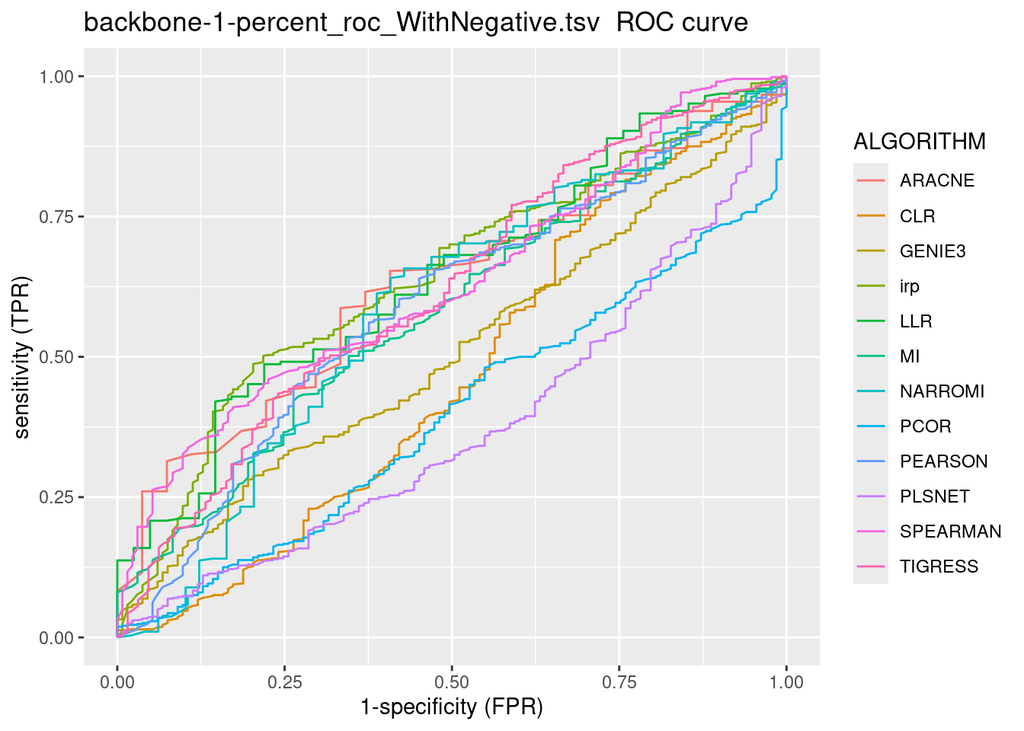

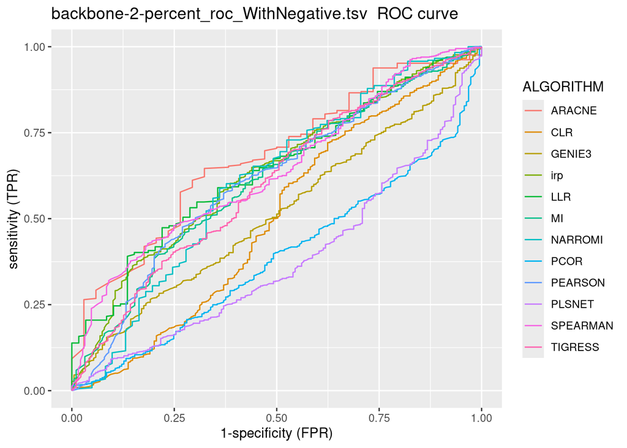

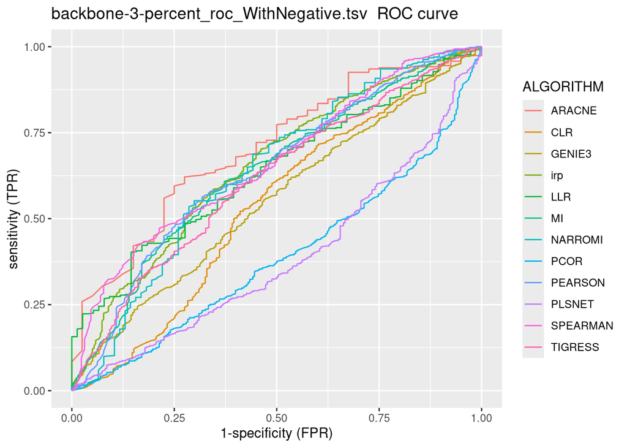

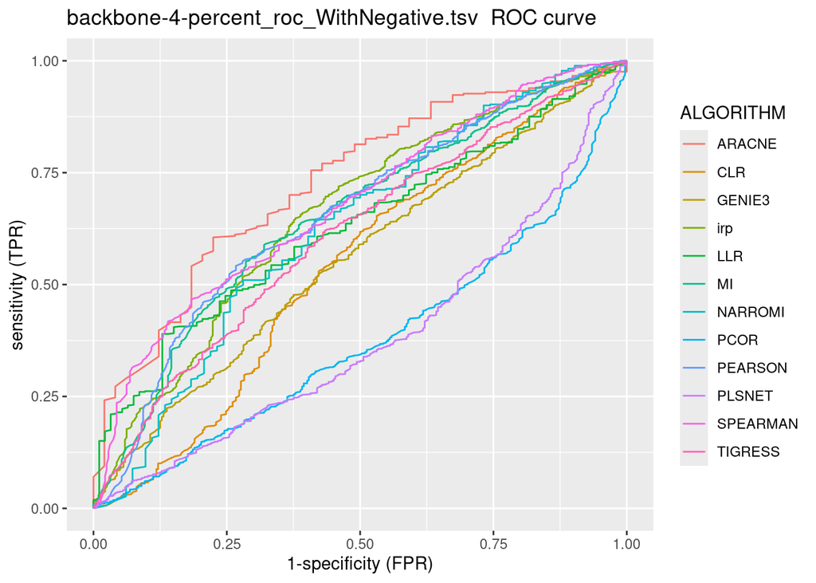

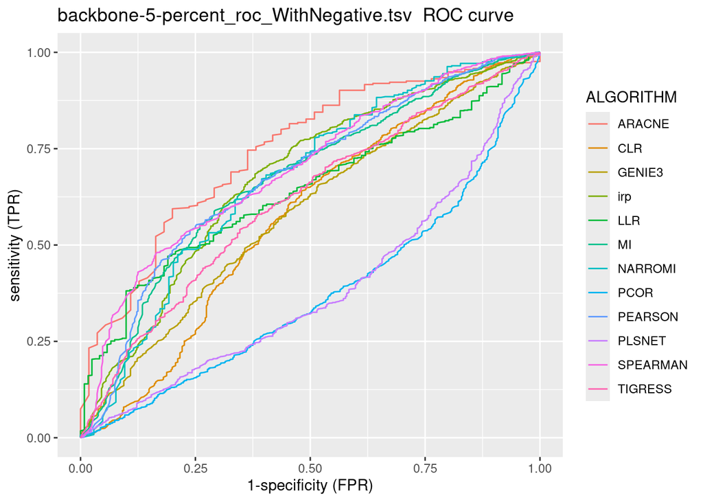

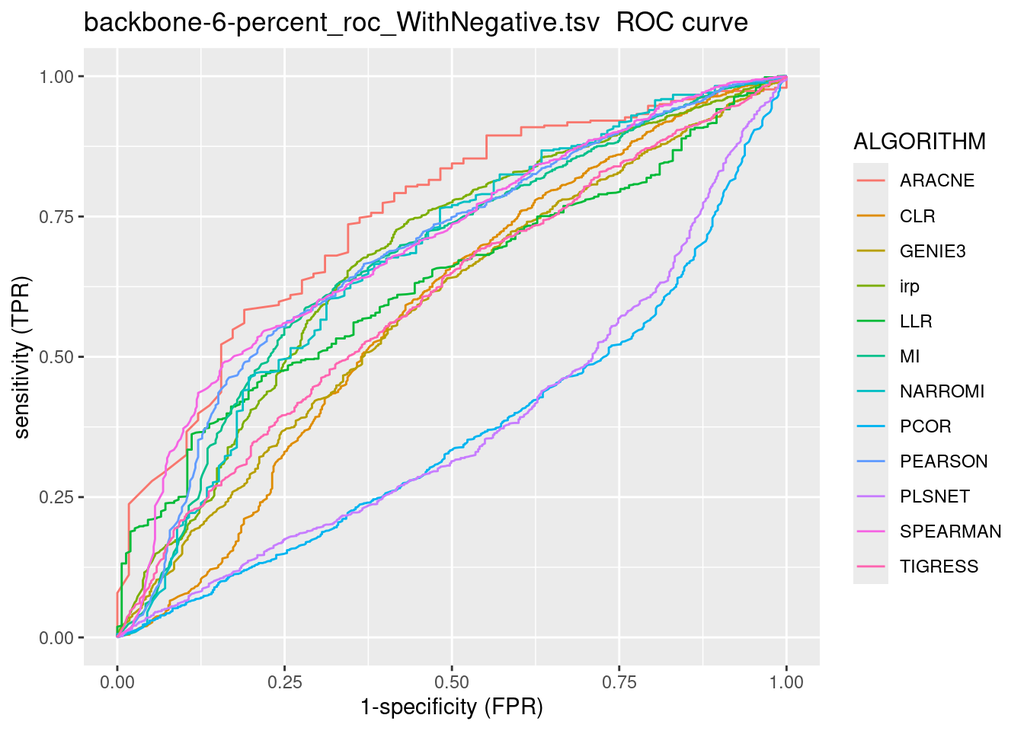

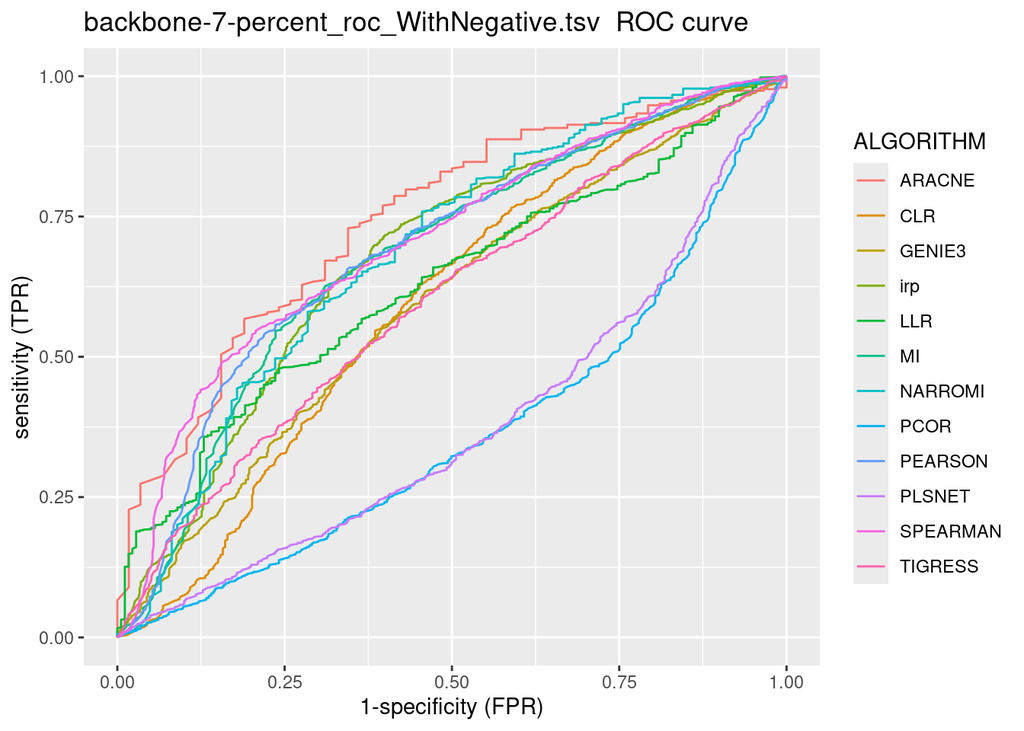

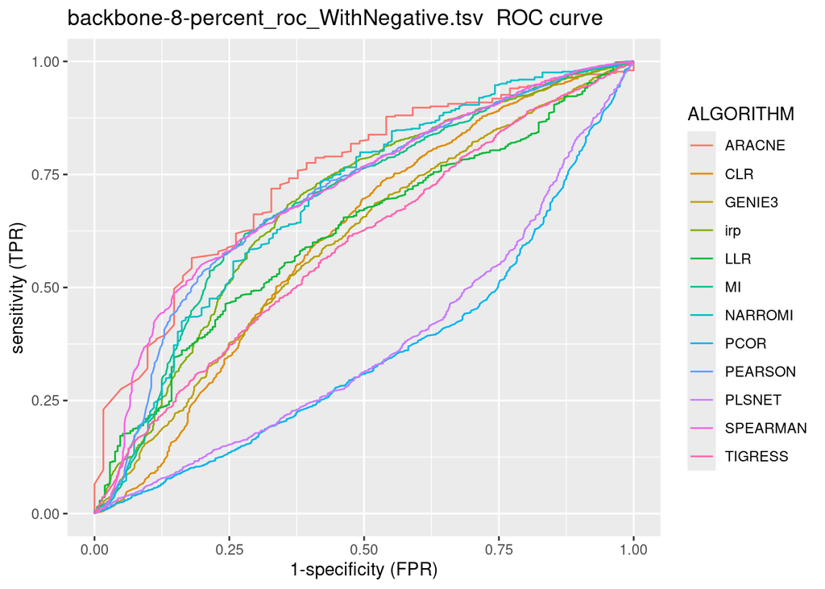

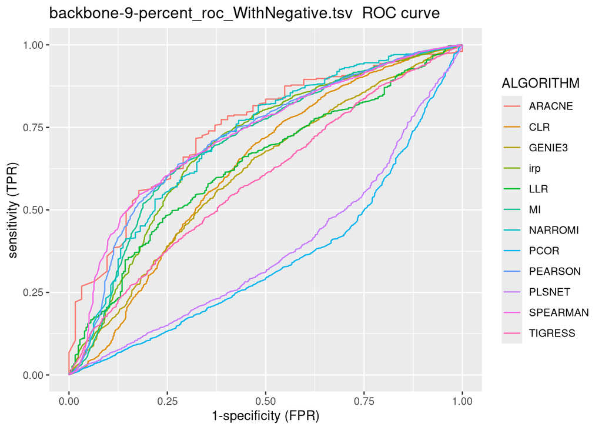

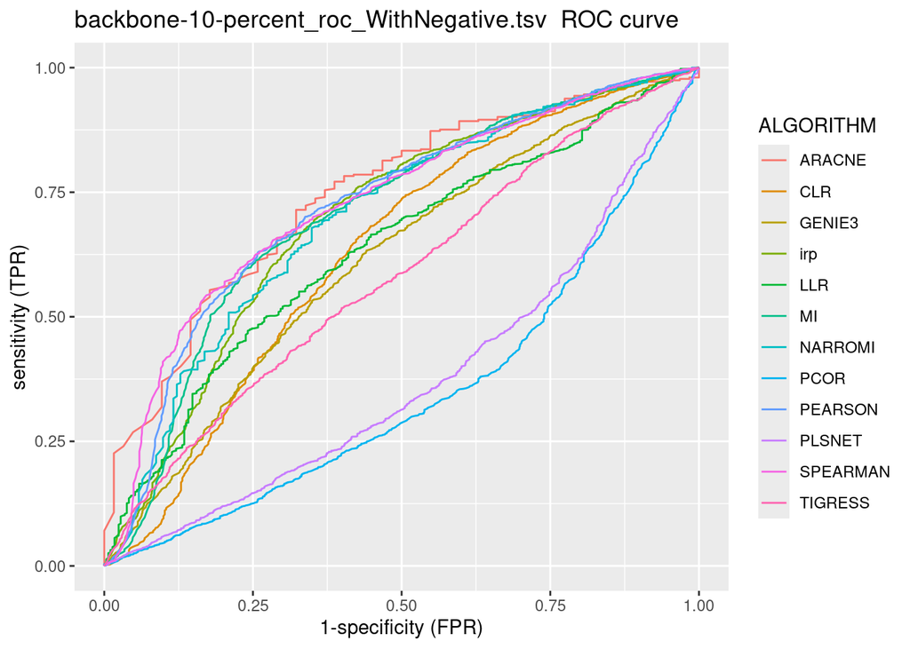

```r
files <- dir(here("data/seidr/results/ResRoc/"),pattern="backbone.*WithNegative\\.tsv",full.names=TRUE)
names(files) <- gsub("backbone-|_roc_WithNegative.tsv","",basename(files))
files <- files[order(as.integer(sub("-percent","",names(files))))]
resb <- lapply(files,plotRoc)
```

### 2.2.1 Stats of the gold standard (GS) analysis

```r
pander(resb)
```

- **1-percent**:

  | ALGO | TP | FP | AUC | AUPR |
  | --- | --- | --- | --- | --- |
  | ARACNE | 242 | 27 | 0.6301 | 0.02903 |
  | CLR | 624 | 133 | 0.4651 | 0.006427 |
  | GENIE3 | 623 | 133 | 0.5075 | 0.007622 |
  | LLR | 226 | 41 | 0.6409 | 0.009167 |
  | MI | 624 | 133 | 0.5825 | 0.01531 |
  | NARROMI | 292 | 49 | 0.5879 | 0.02934 |
  | PCOR | 624 | 133 | 0.3949 | 0.002008 |
  | PEARSON | 624 | 133 | 0.5892 | 0.006924 |
  | PLSNET | 624 | 133 | 0.3757 | 0.002271 |
  | SPEARMAN | 624 | 133 | 0.6314 | 0.007234 |
  | TIGRESS | 619 | 129 | 0.6191 | 0.01707 |
  | irp | 624 | 133 | 0.6416 | 0.02049 |

- **2-percent**:

  | ALGO | TP | FP | AUC | AUPR |
  | --- | --- | --- | --- | --- |
  | ARACNE | 291 | 34 | 0.6808 | 0.02978 |
  | CLR | 929 | 189 | 0.4989 | 0.006189 |
  | GENIE3 | 927 | 188 | 0.5146 | 0.007529 |
  | LLR | 361 | 59 | 0.6425 | 0.008708 |
  | MI | 929 | 189 | 0.6132 | 0.01457 |
  | NARROMI | 354 | 61 | 0.6091 | 0.02656 |
  | PCOR | 929 | 189 | 0.3867 | 0.001909 |
  | PEARSON | 929 | 189 | 0.6128 | 0.008001 |
  | PLSNET | 929 | 189 | 0.3776 | 0.002166 |
  | SPEARMAN | 929 | 189 | 0.6393 | 0.008371 |
  | TIGRESS | 921 | 182 | 0.6039 | 0.0144 |
  | irp | 929 | 189 | 0.6341 | 0.01753 |

- **3-percent**:

  | ALGO | TP | FP | AUC | AUPR |
  | --- | --- | --- | --- | --- |
  | ARACNE | 309 | 40 | 0.703 | 0.02887 |
  | CLR | 1217 | 258 | 0.5347 | 0.006066 |
  | GENIE3 | 1213 | 256 | 0.5513 | 0.007461 |
  | LLR | 497 | 76 | 0.6379 | 0.009137 |
  | MI | 1217 | 258 | 0.6367 | 0.01373 |
  | NARROMI | 402 | 77 | 0.6382 | 0.0244 |
  | PCOR | 1217 | 258 | 0.387 | 0.001846 |
  | PEARSON | 1217 | 258 | 0.6389 | 0.008731 |
  | PLSNET | 1217 | 258 | 0.3847 | 0.002092 |
  | SPEARMAN | 1217 | 258 | 0.6616 | 0.009246 |
  | TIGRESS | 1208 | 248 | 0.6131 | 0.0133 |
  | irp | 1217 | 258 | 0.6536 | 0.01577 |

- **4-percent**:

  | ALGO | TP | FP | AUC | AUPR |
  | --- | --- | --- | --- | --- |
  | ARACNE | 327 | 49 | 0.7295 | 0.02799 |
  | CLR | 1565 | 322 | 0.5422 | 0.006033 |
  | GENIE3 | 1558 | 320 | 0.5589 | 0.007291 |
  | LLR | 657 | 93 | 0.6289 | 0.008872 |
  | MI | 1565 | 322 | 0.6516 | 0.0134 |
  | NARROMI | 451 | 82 | 0.6253 | 0.02282 |
  | PCOR | 1565 | 322 | 0.3749 | 0.001849 |
  | PEARSON | 1565 | 322 | 0.6561 | 0.00952 |
  | PLSNET | 1564 | 322 | 0.3802 | 0.002087 |
  | SPEARMAN | 1565 | 322 | 0.6787 | 0.01014 |
  | TIGRESS | 1552 | 309 | 0.6098 | 0.01218 |
  | irp | 1565 | 322 | 0.6576 | 0.01438 |

- **5-percent**:

  | ALGO | TP | FP | AUC | AUPR |
  | --- | --- | --- | --- | --- |
  | ARACNE | 335 | 55 | 0.7461 | 0.02743 |
  | CLR | 1952 | 416 | 0.5727 | 0.006124 |
  | GENIE3 | 1943 | 414 | 0.5845 | 0.00728 |
  | LLR | 845 | 121 | 0.6389 | 0.008342 |
  | MI | 1952 | 416 | 0.6709 | 0.01338 |
  | NARROMI | 487 | 104 | 0.6697 | 0.02209 |
  | PCOR | 1952 | 416 | 0.3702 | 0.001836 |
  | PEARSON | 1952 | 416 | 0.6786 | 0.0104 |
  | PLSNET | 1951 | 416 | 0.3829 | 0.002064 |
  | SPEARMAN | 1952 | 416 | 0.697 | 0.01121 |
  | TIGRESS | 1935 | 398 | 0.6145 | 0.01141 |
  | irp | 1952 | 416 | 0.6756 | 0.01354 |

- **6-percent**:

  | ALGO | TP | FP | AUC | AUPR |
  | --- | --- | --- | --- | --- |
  | ARACNE | 341 | 58 | 0.7486 | 0.02691 |
  | CLR | 2369 | 497 | 0.5843 | 0.006182 |
  | GENIE3 | 2359 | 495 | 0.5888 | 0.007259 |
  | LLR | 1055 | 153 | 0.6329 | 0.008104 |
  | MI | 2369 | 497 | 0.6745 | 0.01327 |
  | NARROMI | 514 | 112 | 0.6725 | 0.02147 |
  | PCOR | 2369 | 497 | 0.3664 | 0.001829 |
  | PEARSON | 2369 | 497 | 0.6856 | 0.01124 |
  | PLSNET | 2368 | 497 | 0.3794 | 0.002051 |
  | SPEARMAN | 2369 | 497 | 0.7002 | 0.01222 |
  | TIGRESS | 2346 | 476 | 0.6029 | 0.0106 |
  | irp | 2369 | 497 | 0.6756 | 0.01293 |

- **7-percent**:

  | ALGO | TP | FP | AUC | AUPR |
  | --- | --- | --- | --- | --- |
  | ARACNE | 347 | 58 | 0.7439 | 0.02653 |
  | CLR | 2784 | 571 | 0.5957 | 0.006219 |
  | GENIE3 | 2769 | 568 | 0.593 | 0.007183 |
  | LLR | 1286 | 178 | 0.6293 | 0.008035 |
  | MI | 2784 | 571 | 0.6806 | 0.01308 |
  | NARROMI | 543 | 123 | 0.6859 | 0.021 |
  | PCOR | 2784 | 571 | 0.3638 | 0.001834 |
  | PEARSON | 2784 | 571 | 0.6923 | 0.01169 |
  | PLSNET | 2783 | 571 | 0.3767 | 0.002047 |
  | SPEARMAN | 2784 | 571 | 0.7067 | 0.01287 |
  | TIGRESS | 2755 | 549 | 0.5996 | 0.01004 |
  | irp | 2784 | 571 | 0.6794 | 0.01253 |

- **8-percent**:

  | ALGO | TP | FP | AUC | AUPR |
  | --- | --- | --- | --- | --- |
  | ARACNE | 352 | 61 | 0.745 | 0.02614 |
  | CLR | 3267 | 665 | 0.6076 | 0.006266 |
  | GENIE3 | 3249 | 660 | 0.5987 | 0.007069 |
  | LLR | 1541 | 210 | 0.6195 | 0.007697 |
  | MI | 3267 | 665 | 0.6897 | 0.0129 |
  | NARROMI | 572 | 136 | 0.6943 | 0.02026 |
  | PCOR | 3267 | 665 | 0.3582 | 0.001823 |
  | PEARSON | 3267 | 665 | 0.7028 | 0.01214 |
  | PLSNET | 3266 | 665 | 0.376 | 0.002034 |
  | SPEARMAN | 3267 | 665 | 0.7143 | 0.01348 |
  | TIGRESS | 3226 | 637 | 0.5923 | 0.009335 |
  | irp | 3267 | 665 | 0.684 | 0.01212 |

- **9-percent**:

  | ALGO | TP | FP | AUC | AUPR |
  | --- | --- | --- | --- | --- |
  | ARACNE | 353 | 62 | 0.7451 | 0.02599 |
  | CLR | 3834 | 803 | 0.6268 | 0.006273 |
  | GENIE3 | 3811 | 795 | 0.61 | 0.006846 |
  | LLR | 1838 | 252 | 0.6355 | 0.007471 |
  | MI | 3834 | 803 | 0.7044 | 0.01256 |
  | NARROMI | 607 | 160 | 0.7118 | 0.01945 |
  | PCOR | 3834 | 803 | 0.3503 | 0.001806 |
  | PEARSON | 3834 | 803 | 0.7181 | 0.01239 |
  | PLSNET | 3832 | 803 | 0.3771 | 0.002014 |
  | SPEARMAN | 3834 | 803 | 0.7251 | 0.01379 |
  | TIGRESS | 3778 | 774 | 0.5887 | 0.008688 |
  | irp | 3834 | 803 | 0.6973 | 0.01172 |

- **10-percent**:

  | ALGO | TP | FP | AUC | AUPR |
  | --- | --- | --- | --- | --- |
  | ARACNE | 354 | 62 | 0.7436 | 0.02588 |
  | CLR | 4428 | 914 | 0.6315 | 0.006288 |
  | GENIE3 | 4400 | 905 | 0.6124 | 0.006696 |
  | LLR | 2140 | 290 | 0.6361 | 0.00722 |
  | MI | 4428 | 914 | 0.707 | 0.01237 |
  | NARROMI | 637 | 172 | 0.6996 | 0.01857 |
  | PCOR | 4428 | 914 | 0.3497 | 0.001789 |
  | PEARSON | 4428 | 914 | 0.7221 | 0.0127 |
  | PLSNET | 4426 | 914 | 0.3742 | 0.00199 |
  | SPEARMAN | 4428 | 914 | 0.7283 | 0.01413 |
  | TIGRESS | 4366 | 882 | 0.5793 | 0.008107 |
  | irp | 4428 | 914 | 0.6973 | 0.01143 |

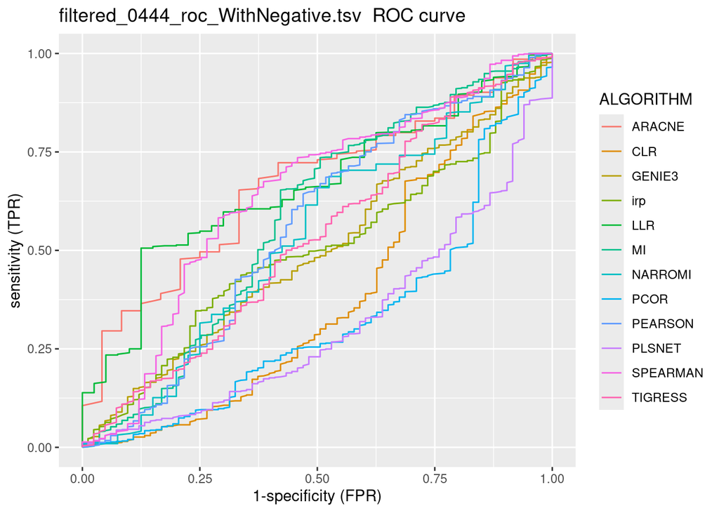

```r
# Hard threshold
reshd <- plotRoc(here("data/seidr/results/ResRoc/filtered_0444_roc_WithNegative.tsv"))
```

### 2.2.2 Stats of the gold standard analysis

```r
pander(reshd)
```

| ALGO | TP | FP | AUC | AUPR |
| --- | --- | --- | --- | --- |
| ARACNE | 274 | 24 | 0.6668 | 0.03257 |
| CLR | 805 | 83 | 0.3803 | 0.0104 |
| GENIE3 | 804 | 83 | 0.5015 | 0.01676 |
| LLR | 512 | 40 | 0.6634 | 0.0227 |
| MI | 805 | 83 | 0.5826 | 0.01659 |
| NARROMI | 317 | 40 | 0.5359 | 0.03102 |
| PCOR | 805 | 83 | 0.3234 | 0.007841 |
| PEARSON | 805 | 83 | 0.5572 | 0.01269 |
| PLSNET | 805 | 83 | 0.3107 | 0.007789 |
| SPEARMAN | 805 | 83 | 0.6397 | 0.01378 |
| TIGRESS | 803 | 83 | 0.5298 | 0.02241 |
| irp | 805 | 83 | 0.4994 | 0.02172 |

# 3 Summary

Report all AUCs

```r
aucs <- c(lapply(resb,select,c("ALGO","AUC")),aggregated=list(select(res,c("ALGO","AUC"))),
          HardThreshold=list(select(reshd,c("ALGO","AUC")))) %>%
  enframe %>% unnest(cols=c("value")) %>% pivot_wider(names_from=name,values_from=AUC) %>%
  column_to_rownames("ALGO") %>% as.matrix()

pander(aucs)
```

Table continues below

|  | 1-percent | 2-percent | 3-percent | 4-percent | 5-percent |
| --- | --- | --- | --- | --- | --- |
| **ARACNE** | 0.6301 | 0.6808 | 0.703 | 0.7295 | 0.7461 |
| **CLR** | 0.4651 | 0.4989 | 0.5347 | 0.5422 | 0.5727 |
| **GENIE3** | 0.5075 | 0.5146 | 0.5513 | 0.5589 | 0.5845 |
| **LLR** | 0.6409 | 0.6425 | 0.6379 | 0.6289 | 0.6389 |
| **MI** | 0.5825 | 0.6132 | 0.6367 | 0.6516 | 0.6709 |
| **NARROMI** | 0.5879 | 0.6091 | 0.6382 | 0.6253 | 0.6697 |
| **PCOR** | 0.3949 | 0.3867 | 0.387 | 0.3749 | 0.3702 |
| **PEARSON** | 0.5892 | 0.6128 | 0.6389 | 0.6561 | 0.6786 |
| **PLSNET** | 0.3757 | 0.3776 | 0.3847 | 0.3802 | 0.3829 |
| **SPEARMAN** | 0.6314 | 0.6393 | 0.6616 | 0.6787 | 0.697 |
| **TIGRESS** | 0.6191 | 0.6039 | 0.6131 | 0.6098 | 0.6145 |
| **irp** | 0.6416 | 0.6341 | 0.6536 | 0.6576 | 0.6756 |

Table continues below

|  | 6-percent | 7-percent | 8-percent | 9-percent | 10-percent |
| --- | --- | --- | --- | --- | --- |
| **ARACNE** | 0.7486 | 0.7439 | 0.745 | 0.7451 | 0.7436 |
| **CLR** | 0.5843 | 0.5957 | 0.6076 | 0.6268 | 0.6315 |
| **GENIE3** | 0.5888 | 0.593 | 0.5987 | 0.61 | 0.6124 |
| **LLR** | 0.6329 | 0.6293 | 0.6195 | 0.6355 | 0.6361 |
| **MI** | 0.6745 | 0.6806 | 0.6897 | 0.7044 | 0.707 |
| **NARROMI** | 0.6725 | 0.6859 | 0.6943 | 0.7118 | 0.6996 |
| **PCOR** | 0.3664 | 0.3638 | 0.3582 | 0.3503 | 0.3497 |
| **PEARSON** | 0.6856 | 0.6923 | 0.7028 | 0.7181 | 0.7221 |
| **PLSNET** | 0.3794 | 0.3767 | 0.376 | 0.3771 | 0.3742 |
| **SPEARMAN** | 0.7002 | 0.7067 | 0.7143 | 0.7251 | 0.7283 |
| **TIGRESS** | 0.6029 | 0.5996 | 0.5923 | 0.5887 | 0.5793 |
| **irp** | 0.6756 | 0.6794 | 0.684 | 0.6973 | 0.6973 |

|  | aggregated | HardThreshold |
| --- | --- | --- |
| **ARACNE** | 0.7574 | 0.6668 |
| **CLR** | 0.5665 | 0.3803 |
| **GENIE3** | 0.5404 | 0.5015 |
| **LLR** | 0.5649 | 0.6634 |
| **MI** | 0.5514 | 0.5826 |
| **NARROMI** | 0.5088 | 0.5359 |
| **PCOR** | 0.5266 | 0.3234 |
| **PEARSON** | 0.5499 | 0.5572 |
| **PLSNET** | 0.5316 | 0.3107 |
| **SPEARMAN** | 0.5513 | 0.6397 |
| **TIGRESS** | 0.5751 | 0.5298 |
| **irp** | 0.5519 | 0.4994 |

## 3.1 Heatmaps

### 3.1.1 AUCs

**NOTE** In the heatmap below, the only fair comparisons are to look across the `aggregated` column or the `irp` row. Any other comparisons, albeit possibly informative will be biased by the selection of a subset of edges for a given algorithm, making them theoretically incomparable.

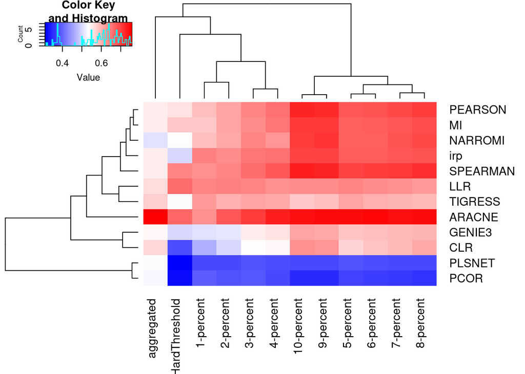

```r
heatmap.2(aucs,trace="none",col=hpal,margins=c(7.1,7.1))
```

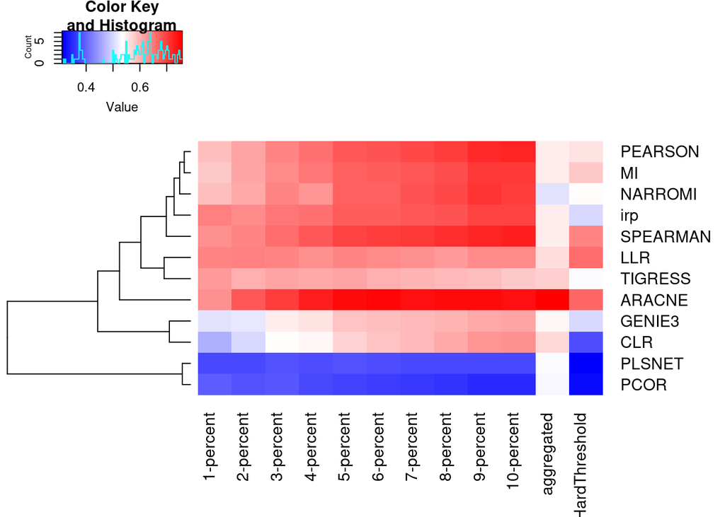

```r
heatmap.2(aucs,trace="none",col=hpal,margins=c(7.1,7.1),Colv=FALSE,dendrogram="row")
```

### 3.1.2 AUCs penalised by the number of Gold Standard (GS) edges used

The rationale here is to check the effect of a limited number of GS on the AUC calculation

```r
resb$aggregated=res
resb$hardthres=reshd

gsNum <- lapply(resb,select,c("ALGO","TP","FP")) %>%
  enframe %>% unnest(cols=c("value")) %>%
  mutate(TOTAL=TP+FP) %>% select(-c("TP","FP")) %>%
  pivot_wider(names_from=name,values_from=TOTAL) %>%
  column_to_rownames("ALGO") %>% as.matrix()

paucs <- aucs * t(t(gsNum) / colMaxs(gsNum))

pander(paucs)
```

Table continues below

|  | 1-percent | 2-percent | 3-percent | 4-percent | 5-percent |
| --- | --- | --- | --- | --- | --- |
| **ARACNE** | 0.2239 | 0.1979 | 0.1663 | 0.1454 | 0.1229 |
| **CLR** | 0.4651 | 0.4989 | 0.5347 | 0.5422 | 0.5727 |
| **GENIE3** | 0.5068 | 0.5132 | 0.549 | 0.5562 | 0.5817 |
| **LLR** | 0.2261 | 0.2414 | 0.2478 | 0.25 | 0.2606 |
| **MI** | 0.5825 | 0.6132 | 0.6367 | 0.6516 | 0.6709 |
| **NARROMI** | 0.2648 | 0.2261 | 0.2072 | 0.1766 | 0.1671 |
| **PCOR** | 0.3949 | 0.3867 | 0.387 | 0.3749 | 0.3702 |
| **PEARSON** | 0.5892 | 0.6128 | 0.6389 | 0.6561 | 0.6786 |
| **PLSNET** | 0.3757 | 0.3776 | 0.3847 | 0.38 | 0.3827 |
| **SPEARMAN** | 0.6314 | 0.6393 | 0.6616 | 0.6787 | 0.697 |
| **TIGRESS** | 0.6118 | 0.5958 | 0.6052 | 0.6014 | 0.6054 |
| **irp** | 0.6416 | 0.6341 | 0.6536 | 0.6576 | 0.6756 |

Table continues below

|  | 6-percent | 7-percent | 8-percent | 9-percent | 10-percent |
| --- | --- | --- | --- | --- | --- |
| **ARACNE** | 0.1042 | 0.0898 | 0.07825 | 0.06668 | 0.05791 |
| **CLR** | 0.5843 | 0.5957 | 0.6076 | 0.6268 | 0.6315 |
| **GENIE3** | 0.5863 | 0.5898 | 0.5952 | 0.6059 | 0.6081 |
| **LLR** | 0.2667 | 0.2746 | 0.2759 | 0.2864 | 0.2894 |
| **MI** | 0.6745 | 0.6806 | 0.6897 | 0.7044 | 0.707 |
| **NARROMI** | 0.1469 | 0.1362 | 0.125 | 0.1177 | 0.106 |
| **PCOR** | 0.3664 | 0.3638 | 0.3582 | 0.3503 | 0.3497 |
| **PEARSON** | 0.6856 | 0.6923 | 0.7028 | 0.7181 | 0.7221 |
| **PLSNET** | 0.3792 | 0.3766 | 0.3759 | 0.377 | 0.3741 |
| **SPEARMAN** | 0.7002 | 0.7067 | 0.7143 | 0.7251 | 0.7283 |
| **TIGRESS** | 0.5937 | 0.5905 | 0.5819 | 0.5779 | 0.5691 |
| **irp** | 0.6756 | 0.6794 | 0.684 | 0.6973 | 0.6973 |

|  | aggregated | HardThreshold |
| --- | --- | --- |
| **ARACNE** | 0.0006718 | 0.2238 |
| **CLR** | 0.2939 | 0.3803 |
| **GENIE3** | 0.3336 | 0.5009 |
| **LLR** | 0.2277 | 0.4124 |
| **MI** | 0.5514 | 0.5826 |
| **NARROMI** | 0.4045 | 0.2154 |
| **PCOR** | 0.5266 | 0.3234 |
| **PEARSON** | 0.5499 | 0.5572 |
| **PLSNET** | 0.5311 | 0.3107 |
| **SPEARMAN** | 0.5513 | 0.6397 |
| **TIGRESS** | 0.1039 | 0.5286 |
| **irp** | 0.5519 | 0.4994 |

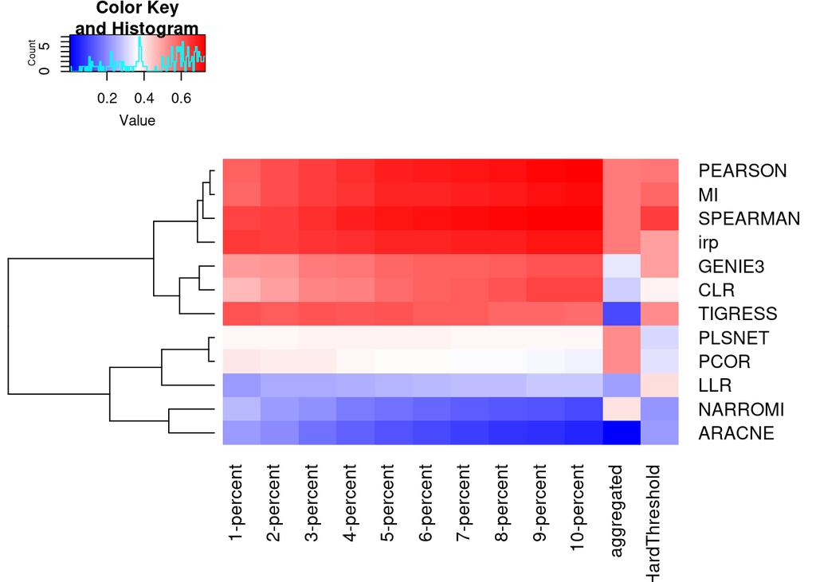

```r
heatmap.2(paucs,trace="none",col=hpal,margins=c(7.1,7.1),Colv=FALSE,dendrogram="row")
```

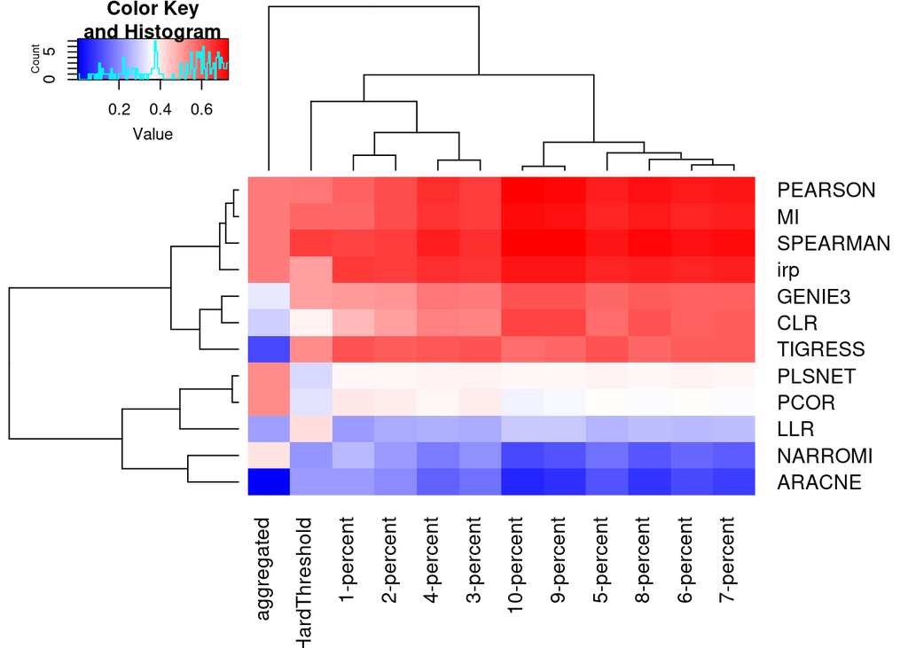

```r
heatmap.2(paucs,trace="none",col=hpal,margins=c(7.1,7.1))
```

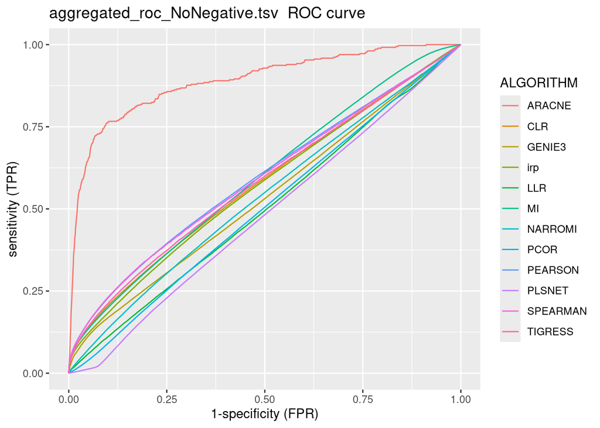

```r
#WithNegative data seem to suggest using as threshold backbone 9 or 5.

# Now repeat everything with NoNegatives.
res <- plotRoc(here("data/seidr/results/ResRoc/aggregated_roc_NoNegative.tsv"))
```

### 3.1.3 Stats of the gold standard analysis

```r
pander(res)
```

| ALGO | TP | FP | AUC | AUPR |
| --- | --- | --- | --- | --- |
| ARACNE | 364 | 252899 | 0.8892 | 0.02513 |
| CLR | 133121 | 204441630 | 0.5769 | 0.001317 |
| GENIE3 | 150917 | 217495426 | 0.5333 | 0.001046 |
| LLR | 102155 | 163820719 | 0.5006 | 0.0006462 |
| MI | 243030 | 437555815 | 0.5933 | 0.001279 |
| NARROMI | 183602 | 387765697 | 0.5358 | 0.0006217 |
| PCOR | 243030 | 437555815 | 0.5014 | 0.0005456 |
| PEARSON | 243030 | 437555815 | 0.5935 | 0.001563 |
| PLSNET | 242772 | 435595884 | 0.4799 | 0.0005039 |
| SPEARMAN | 243027 | 437543224 | 0.5908 | 0.001575 |
| TIGRESS | 48379 | 70162956 | 0.5806 | 0.001642 |
| irp | 243030 | 437555815 | 0.5695 | 0.001217 |

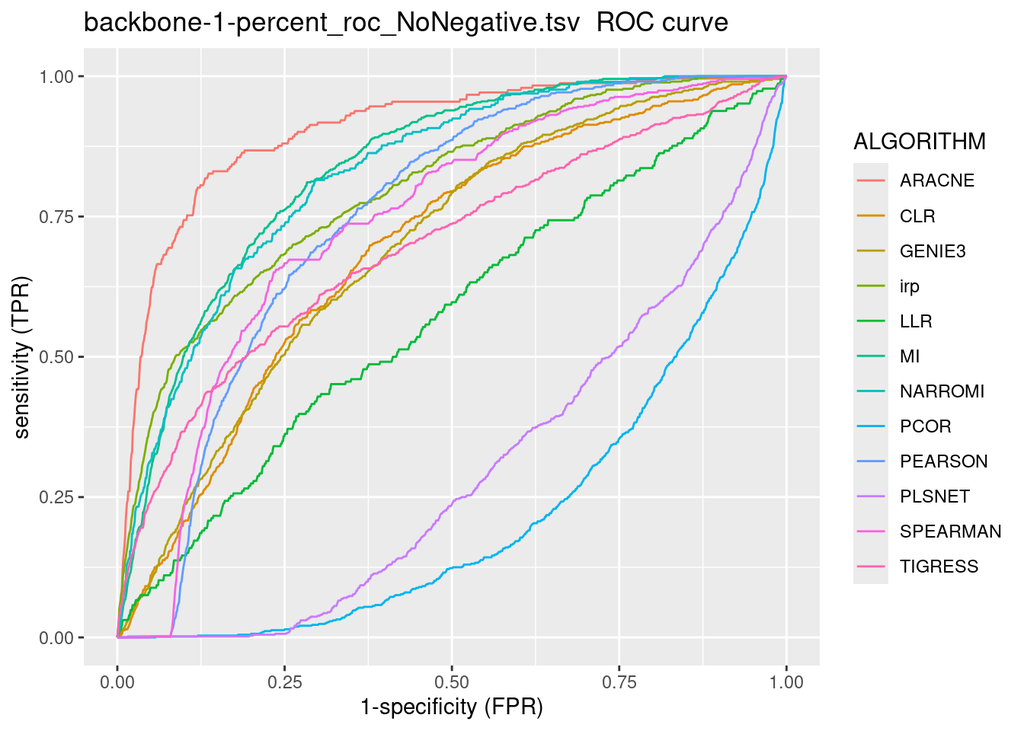

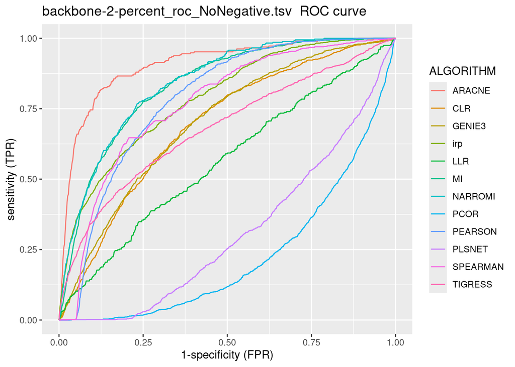

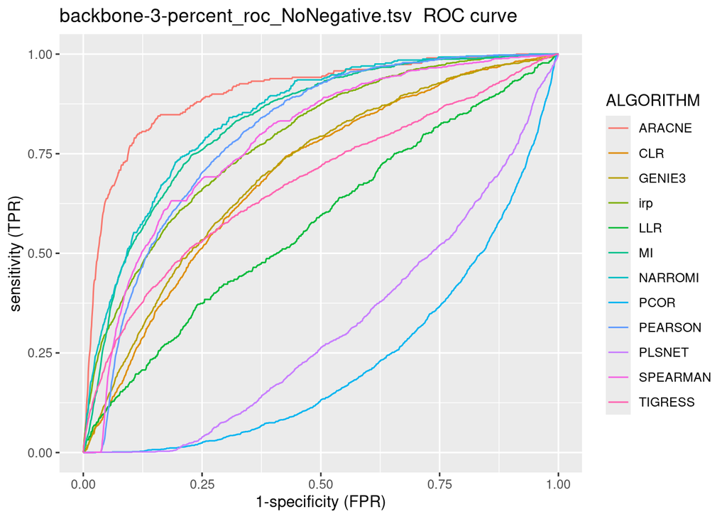

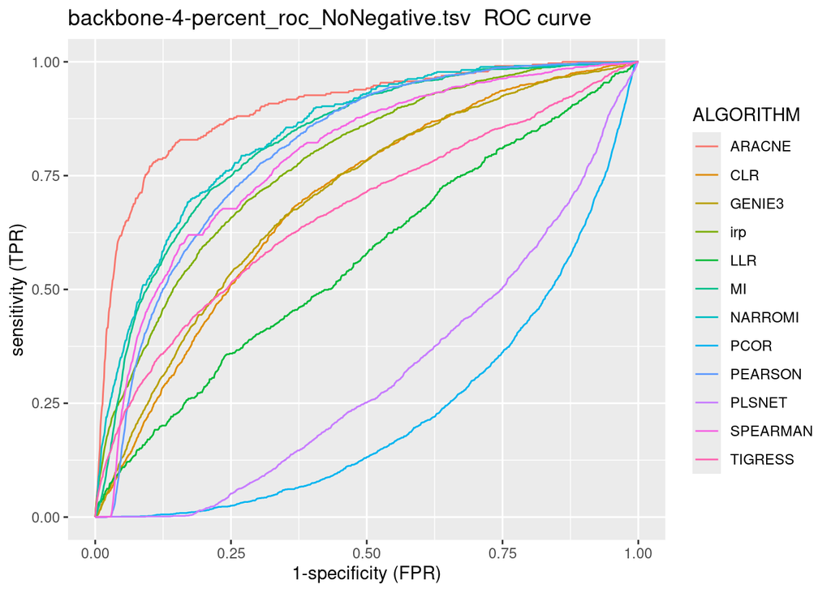

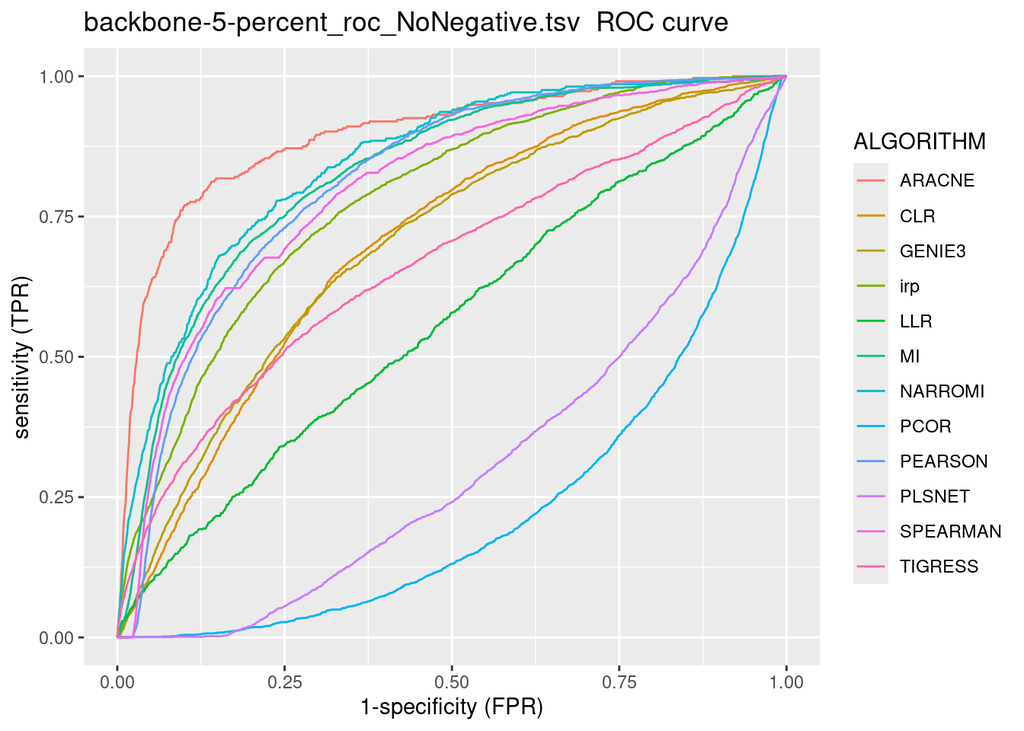

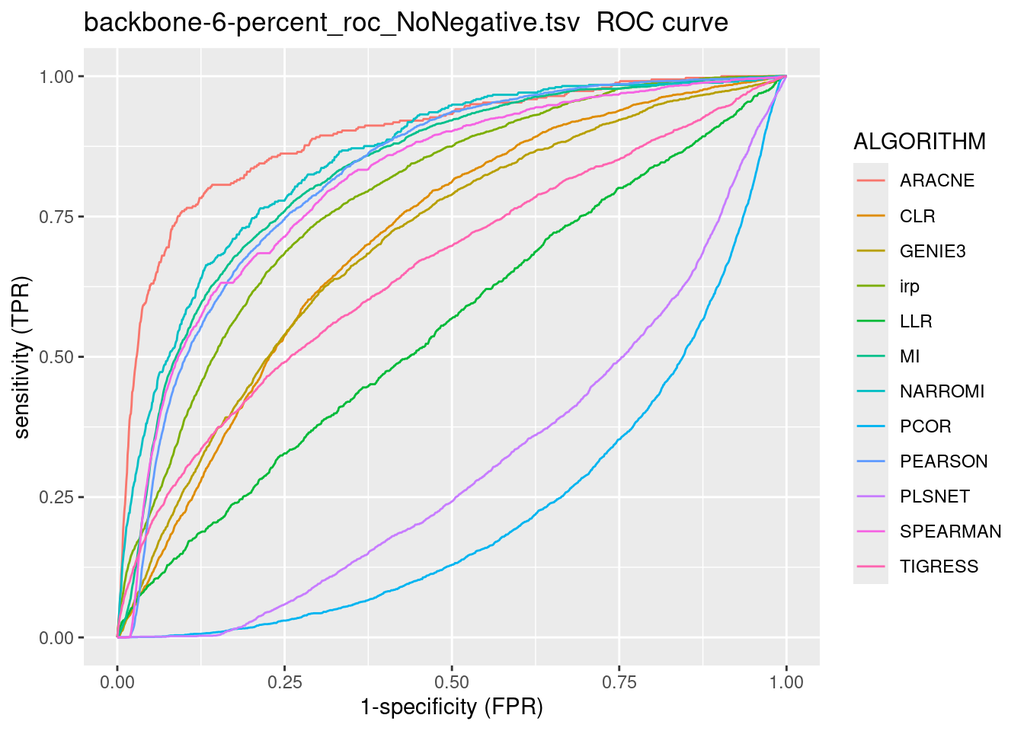

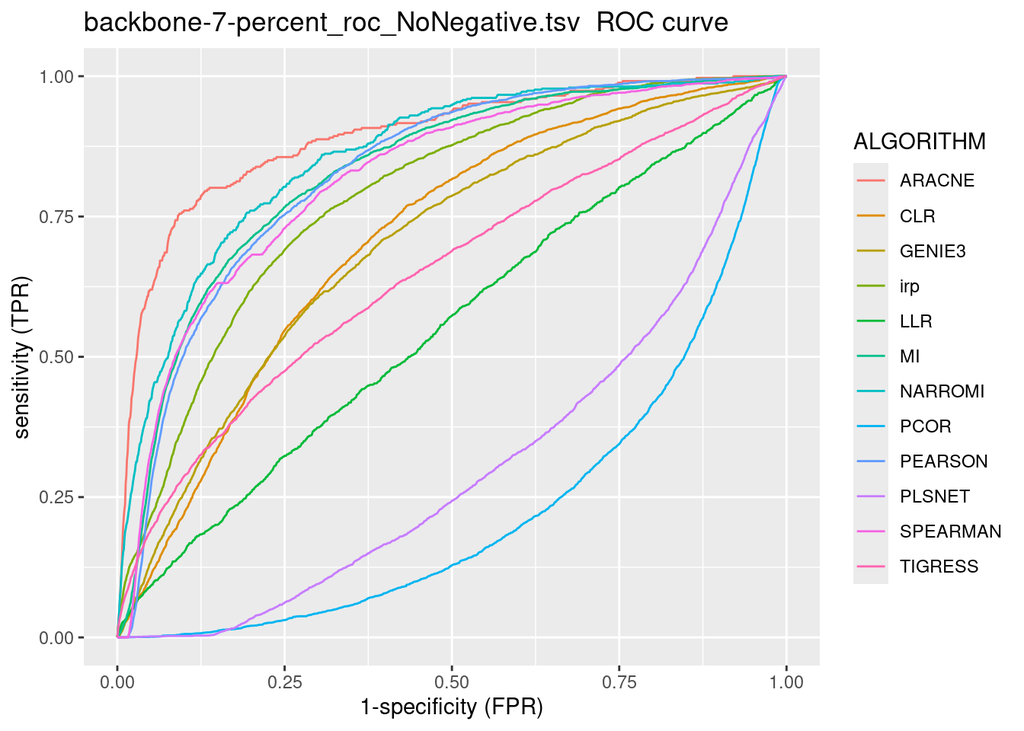

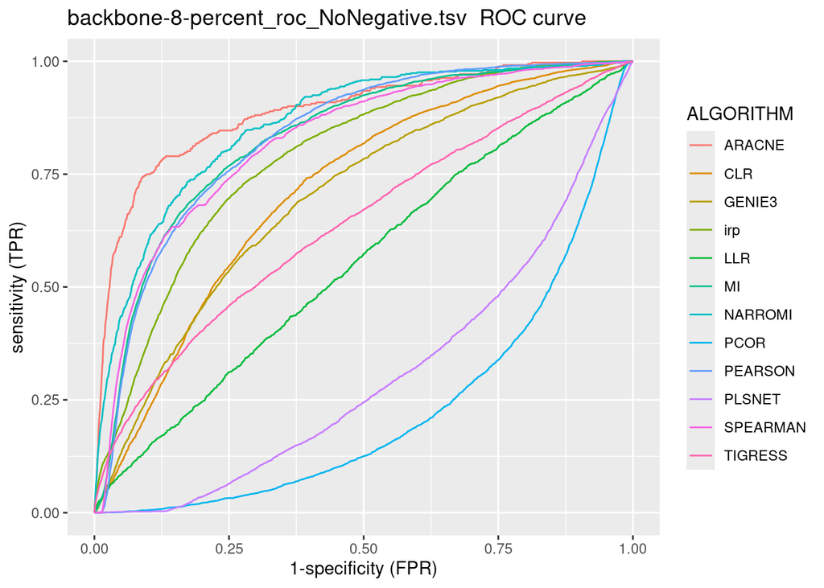

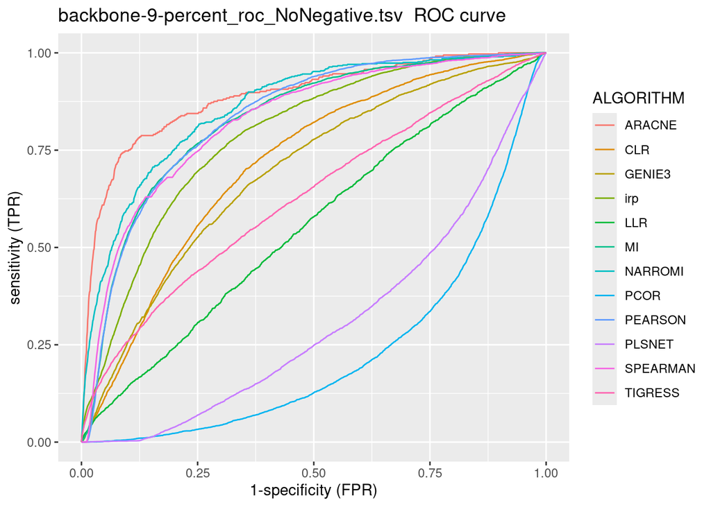

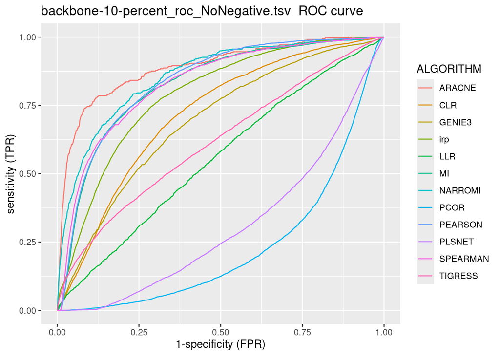

```r
files <- dir(here("data/seidr/results/ResRoc/"),pattern="backbone.*NoNegative\\.tsv",full.names=TRUE)
names(files) <- gsub("backbone-|_roc_NoNegative.tsv","",basename(files))
files <- files[order(as.integer(sub("-percent","",names(files))))]
resb <- lapply(files,plotRoc)
```

### 3.1.4 Stats of the gold standard (GS) analysis

```r
pander(resb)
```

- **1-percent**:

  | ALGO | TP | FP | AUC | AUPR |
  | --- | --- | --- | --- | --- |
  | ARACNE | 242 | 89307 | 0.9046 | 0.02903 |
  | CLR | 624 | 178890 | 0.6928 | 0.006427 |
  | GENIE3 | 623 | 150735 | 0.6946 | 0.007622 |
  | LLR | 226 | 33657 | 0.5705 | 0.009167 |
  | MI | 624 | 178890 | 0.8353 | 0.01531 |
  | NARROMI | 292 | 45398 | 0.8272 | 0.02934 |
  | PCOR | 624 | 178890 | 0.2188 | 0.002008 |
  | PEARSON | 624 | 178890 | 0.7481 | 0.006924 |
  | PLSNET | 624 | 174930 | 0.3002 | 0.002271 |
  | SPEARMAN | 624 | 178890 | 0.7376 | 0.007234 |
  | TIGRESS | 619 | 129082 | 0.6975 | 0.01707 |
  | irp | 624 | 178890 | 0.7983 | 0.02049 |

- **2-percent**:

  | ALGO | TP | FP | AUC | AUPR |
  | --- | --- | --- | --- | --- |
  | ARACNE | 291 | 114968 | 0.9075 | 0.02978 |
  | CLR | 929 | 282182 | 0.6914 | 0.006189 |
  | GENIE3 | 927 | 242938 | 0.6987 | 0.007529 |
  | LLR | 361 | 56695 | 0.562 | 0.008708 |
  | MI | 929 | 282182 | 0.8332 | 0.01457 |
  | NARROMI | 354 | 70389 | 0.8412 | 0.02656 |
  | PCOR | 929 | 282182 | 0.2263 | 0.001909 |
  | PEARSON | 929 | 282182 | 0.7827 | 0.008001 |
  | PLSNET | 929 | 276779 | 0.3107 | 0.002166 |
  | SPEARMAN | 929 | 282182 | 0.767 | 0.008371 |
  | TIGRESS | 921 | 214290 | 0.6796 | 0.0144 |
  | irp | 929 | 282182 | 0.7867 | 0.01753 |

- **3-percent**:

  | ALGO | TP | FP | AUC | AUPR |
  | --- | --- | --- | --- | --- |
  | ARACNE | 309 | 132663 | 0.9029 | 0.02887 |
  | CLR | 1217 | 383844 | 0.6933 | 0.006066 |
  | GENIE3 | 1213 | 333534 | 0.7037 | 0.007461 |
  | LLR | 497 | 80695 | 0.5749 | 0.009137 |
  | MI | 1217 | 383844 | 0.83 | 0.01373 |
  | NARROMI | 402 | 94667 | 0.8441 | 0.0244 |
  | PCOR | 1217 | 383844 | 0.2304 | 0.001846 |
  | PEARSON | 1217 | 383844 | 0.7967 | 0.008731 |
  | PLSNET | 1217 | 377048 | 0.3143 | 0.002092 |
  | SPEARMAN | 1217 | 383844 | 0.7817 | 0.009246 |
  | TIGRESS | 1208 | 299624 | 0.6764 | 0.0133 |
  | irp | 1217 | 383844 | 0.7852 | 0.01577 |

- **4-percent**:

  | ALGO | TP | FP | AUC | AUPR |
  | --- | --- | --- | --- | --- |
  | ARACNE | 327 | 146893 | 0.898 | 0.02799 |
  | CLR | 1565 | 493153 | 0.6939 | 0.006033 |
  | GENIE3 | 1558 | 431771 | 0.6991 | 0.007291 |
  | LLR | 657 | 107543 | 0.565 | 0.008872 |
  | MI | 1565 | 493153 | 0.8264 | 0.0134 |
  | NARROMI | 451 | 120320 | 0.84 | 0.02282 |
  | PCOR | 1565 | 493153 | 0.2309 | 0.001849 |
  | PEARSON | 1565 | 493153 | 0.8031 | 0.00952 |
  | PLSNET | 1564 | 485215 | 0.3138 | 0.002087 |
  | SPEARMAN | 1565 | 493153 | 0.7873 | 0.01014 |
  | TIGRESS | 1552 | 393443 | 0.6679 | 0.01218 |
  | irp | 1565 | 493153 | 0.7786 | 0.01438 |

- **5-percent**:

  | ALGO | TP | FP | AUC | AUPR |
  | --- | --- | --- | --- | --- |
  | ARACNE | 335 | 159352 | 0.8952 | 0.02743 |
  | CLR | 1952 | 619023 | 0.7015 | 0.006124 |
  | GENIE3 | 1943 | 544931 | 0.7005 | 0.00728 |
  | LLR | 845 | 139500 | 0.56 | 0.008342 |
  | MI | 1952 | 619023 | 0.8274 | 0.01338 |
  | NARROMI | 487 | 149523 | 0.8458 | 0.02209 |
  | PCOR | 1952 | 619023 | 0.2302 | 0.001836 |
  | PEARSON | 1952 | 619023 | 0.8135 | 0.0104 |
  | PLSNET | 1951 | 609855 | 0.3113 | 0.002064 |
  | SPEARMAN | 1952 | 619023 | 0.7998 | 0.01121 |
  | TIGRESS | 1935 | 502810 | 0.663 | 0.01141 |
  | irp | 1952 | 619023 | 0.7808 | 0.01354 |

- **6-percent**:

  | ALGO | TP | FP | AUC | AUPR |
  | --- | --- | --- | --- | --- |
  | ARACNE | 341 | 169533 | 0.8936 | 0.02691 |
  | CLR | 2369 | 753543 | 0.7078 | 0.006182 |
  | GENIE3 | 2359 | 665696 | 0.701 | 0.007259 |
  | LLR | 1055 | 174921 | 0.552 | 0.008104 |
  | MI | 2369 | 753543 | 0.8294 | 0.01327 |
  | NARROMI | 514 | 179939 | 0.8523 | 0.02147 |
  | PCOR | 2369 | 753543 | 0.2293 | 0.001829 |
  | PEARSON | 2369 | 753543 | 0.8221 | 0.01124 |
  | PLSNET | 2368 | 743170 | 0.3101 | 0.002051 |
  | SPEARMAN | 2369 | 753543 | 0.8114 | 0.01222 |
  | TIGRESS | 2346 | 620463 | 0.656 | 0.0106 |
  | irp | 2369 | 753543 | 0.7846 | 0.01293 |

- **7-percent**:

  | ALGO | TP | FP | AUC | AUPR |
  | --- | --- | --- | --- | --- |
  | ARACNE | 347 | 177613 | 0.8925 | 0.02653 |
  | CLR | 2784 | 883775 | 0.7101 | 0.006219 |
  | GENIE3 | 2769 | 782486 | 0.6988 | 0.007183 |
  | LLR | 1286 | 209891 | 0.5526 | 0.008035 |
  | MI | 2784 | 883775 | 0.8291 | 0.01308 |
  | NARROMI | 543 | 209410 | 0.8577 | 0.021 |
  | PCOR | 2784 | 883775 | 0.2298 | 0.001834 |
  | PEARSON | 2784 | 883775 | 0.8268 | 0.01169 |
  | PLSNET | 2783 | 872360 | 0.308 | 0.002047 |
  | SPEARMAN | 2784 | 883775 | 0.8178 | 0.01287 |
  | TIGRESS | 2755 | 734923 | 0.6493 | 0.01004 |
  | irp | 2784 | 883775 | 0.7863 | 0.01253 |

- **8-percent**:

  | ALGO | TP | FP | AUC | AUPR |
  | --- | --- | --- | --- | --- |
  | ARACNE | 352 | 185387 | 0.889 | 0.02614 |
  | CLR | 3267 | 1043434 | 0.7134 | 0.006266 |
  | GENIE3 | 3249 | 926244 | 0.6973 | 0.007069 |
  | LLR | 1541 | 253932 | 0.5526 | 0.007697 |
  | MI | 3267 | 1043434 | 0.8296 | 0.0129 |
  | NARROMI | 572 | 245649 | 0.8621 | 0.02026 |
  | PCOR | 3267 | 1043434 | 0.2294 | 0.001823 |
  | PEARSON | 3267 | 1043434 | 0.8312 | 0.01214 |
  | PLSNET | 3266 | 1030757 | 0.3081 | 0.002034 |
  | SPEARMAN | 3267 | 1043434 | 0.823 | 0.01348 |
  | TIGRESS | 3226 | 875908 | 0.6385 | 0.009335 |
  | irp | 3267 | 1043434 | 0.788 | 0.01212 |

- **9-percent**:

  | ALGO | TP | FP | AUC | AUPR |
  | --- | --- | --- | --- | --- |
  | ARACNE | 353 | 193066 | 0.8893 | 0.02599 |
  | CLR | 3834 | 1240138 | 0.715 | 0.006273 |
  | GENIE3 | 3811 | 1102622 | 0.6923 | 0.006846 |
  | LLR | 1838 | 309275 | 0.5546 | 0.007471 |
  | MI | 3834 | 1240139 | 0.8279 | 0.01256 |
  | NARROMI | 607 | 290393 | 0.8612 | 0.01945 |
  | PCOR | 3834 | 1240139 | 0.2317 | 0.001806 |
  | PEARSON | 3834 | 1240139 | 0.8341 | 0.01239 |
  | PLSNET | 3832 | 1225917 | 0.311 | 0.002014 |
  | SPEARMAN | 3834 | 1240139 | 0.8266 | 0.01379 |
  | TIGRESS | 3778 | 1049700 | 0.6274 | 0.008688 |
  | irp | 3834 | 1240139 | 0.7885 | 0.01172 |

- **10-percent**:

  | ALGO | TP | FP | AUC | AUPR |
  | --- | --- | --- | --- | --- |
  | ARACNE | 354 | 199302 | 0.8894 | 0.02588 |
  | CLR | 4428 | 1446585 | 0.717 | 0.006288 |
  | GENIE3 | 4400 | 1287342 | 0.6902 | 0.006696 |
  | LLR | 2140 | 368422 | 0.5558 | 0.00722 |
  | MI | 4428 | 1446589 | 0.8267 | 0.01237 |
  | NARROMI | 637 | 337934 | 0.8574 | 0.01857 |
  | PCOR | 4428 | 1446589 | 0.2319 | 0.001789 |
  | PEARSON | 4428 | 1446589 | 0.8368 | 0.0127 |
  | PLSNET | 4426 | 1430788 | 0.3098 | 0.00199 |
  | SPEARMAN | 4428 | 1446589 | 0.8304 | 0.01413 |
  | TIGRESS | 4366 | 1231841 | 0.6154 | 0.008107 |
  | irp | 4428 | 1446589 | 0.789 | 0.01143 |

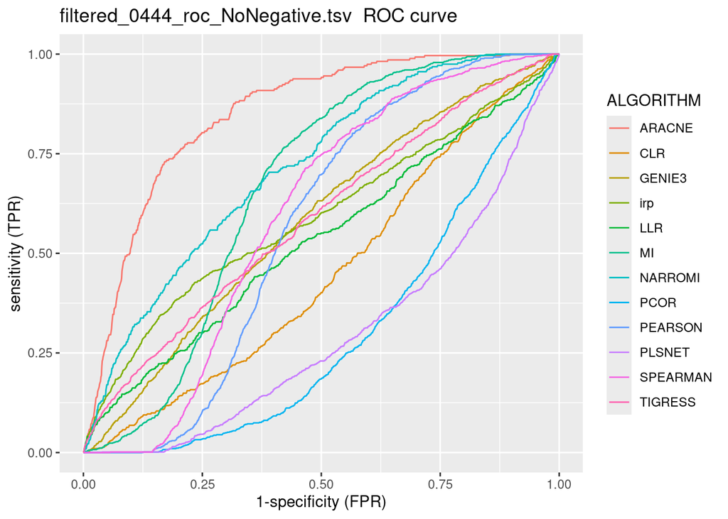

```r
# Hard threshold
reshd <- plotRoc(here("data/seidr/results/ResRoc/filtered_0444_roc_NoNegative.tsv"))
```

### 3.1.5 Stats of the gold standard analysis

```r
pander(reshd)
```

| ALGO | TP | FP | AUC | AUPR |
| --- | --- | --- | --- | --- |
| ARACNE | 274 | 35673 | 0.8489 | 0.03257 |
| CLR | 805 | 65054 | 0.4519 | 0.0104 |
| GENIE3 | 804 | 56777 | 0.5812 | 0.01676 |
| LLR | 512 | 29927 | 0.5332 | 0.0227 |
| MI | 805 | 65054 | 0.6654 | 0.01659 |
| NARROMI | 317 | 22493 | 0.7167 | 0.03102 |
| PCOR | 805 | 65054 | 0.3007 | 0.007841 |
| PEARSON | 805 | 65054 | 0.5646 | 0.01269 |
| PLSNET | 805 | 64960 | 0.2975 | 0.007789 |
| SPEARMAN | 805 | 65054 | 0.594 | 0.01378 |
| TIGRESS | 803 | 54142 | 0.5875 | 0.02241 |
| irp | 805 | 65054 | 0.5905 | 0.02172 |

# 4 Summary

Report all AUCs

```r
aucs <- c(lapply(resb,select,c("ALGO","AUC")),aggregated=list(select(res,c("ALGO","AUC"))),
          HardThreshold=list(select(reshd,c("ALGO","AUC")))) %>%
  enframe %>% unnest(cols=c("value")) %>% pivot_wider(names_from=name,values_from=AUC) %>%
  column_to_rownames("ALGO") %>% as.matrix()

pander(aucs)
```

Table continues below

|  | 1-percent | 2-percent | 3-percent | 4-percent | 5-percent |
| --- | --- | --- | --- | --- | --- |
| **ARACNE** | 0.9046 | 0.9075 | 0.9029 | 0.898 | 0.8952 |
| **CLR** | 0.6928 | 0.6914 | 0.6933 | 0.6939 | 0.7015 |
| **GENIE3** | 0.6946 | 0.6987 | 0.7037 | 0.6991 | 0.7005 |
| **LLR** | 0.5705 | 0.562 | 0.5749 | 0.565 | 0.56 |
| **MI** | 0.8353 | 0.8332 | 0.83 | 0.8264 | 0.8274 |
| **NARROMI** | 0.8272 | 0.8412 | 0.8441 | 0.84 | 0.8458 |
| **PCOR** | 0.2188 | 0.2263 | 0.2304 | 0.2309 | 0.2302 |
| **PEARSON** | 0.7481 | 0.7827 | 0.7967 | 0.8031 | 0.8135 |
| **PLSNET** | 0.3002 | 0.3107 | 0.3143 | 0.3138 | 0.3113 |
| **SPEARMAN** | 0.7376 | 0.767 | 0.7817 | 0.7873 | 0.7998 |
| **TIGRESS** | 0.6975 | 0.6796 | 0.6764 | 0.6679 | 0.663 |
| **irp** | 0.7983 | 0.7867 | 0.7852 | 0.7786 | 0.7808 |

Table continues below

|  | 6-percent | 7-percent | 8-percent | 9-percent | 10-percent |
| --- | --- | --- | --- | --- | --- |
| **ARACNE** | 0.8936 | 0.8925 | 0.889 | 0.8893 | 0.8894 |
| **CLR** | 0.7078 | 0.7101 | 0.7134 | 0.715 | 0.717 |
| **GENIE3** | 0.701 | 0.6988 | 0.6973 | 0.6923 | 0.6902 |
| **LLR** | 0.552 | 0.5526 | 0.5526 | 0.5546 | 0.5558 |
| **MI** | 0.8294 | 0.8291 | 0.8296 | 0.8279 | 0.8267 |
| **NARROMI** | 0.8523 | 0.8577 | 0.8621 | 0.8612 | 0.8574 |
| **PCOR** | 0.2293 | 0.2298 | 0.2294 | 0.2317 | 0.2319 |
| **PEARSON** | 0.8221 | 0.8268 | 0.8312 | 0.8341 | 0.8368 |
| **PLSNET** | 0.3101 | 0.308 | 0.3081 | 0.311 | 0.3098 |
| **SPEARMAN** | 0.8114 | 0.8178 | 0.823 | 0.8266 | 0.8304 |
| **TIGRESS** | 0.656 | 0.6493 | 0.6385 | 0.6274 | 0.6154 |
| **irp** | 0.7846 | 0.7863 | 0.788 | 0.7885 | 0.789 |

|  | aggregated | HardThreshold |
| --- | --- | --- |
| **ARACNE** | 0.8892 | 0.8489 |
| **CLR** | 0.5769 | 0.4519 |
| **GENIE3** | 0.5333 | 0.5812 |
| **LLR** | 0.5006 | 0.5332 |
| **MI** | 0.5933 | 0.6654 |
| **NARROMI** | 0.5358 | 0.7167 |
| **PCOR** | 0.5014 | 0.3007 |
| **PEARSON** | 0.5935 | 0.5646 |
| **PLSNET** | 0.4799 | 0.2975 |
| **SPEARMAN** | 0.5908 | 0.594 |
| **TIGRESS** | 0.5806 | 0.5875 |
| **irp** | 0.5695 | 0.5905 |

## 4.1 Heatmaps

### 4.1.1 AUCs

**NOTE** In the heatmap below, the only fair comparisons are to look across the `aggregated` column or the `irp` row. Any other comparisons, albeit possibly informative will be biased by the selection of a subset of edges for a given algorithm, making them theoretically incomparable.

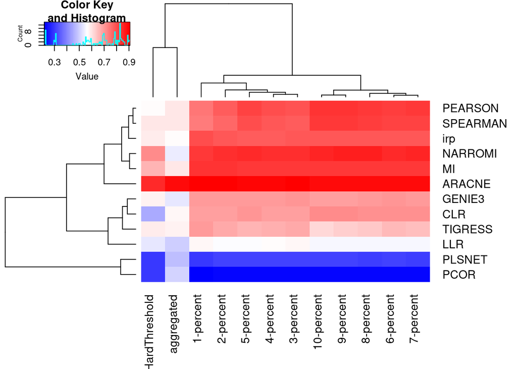

```r
heatmap.2(aucs,trace="none",col=hpal,margins=c(7.1,7.1))
```

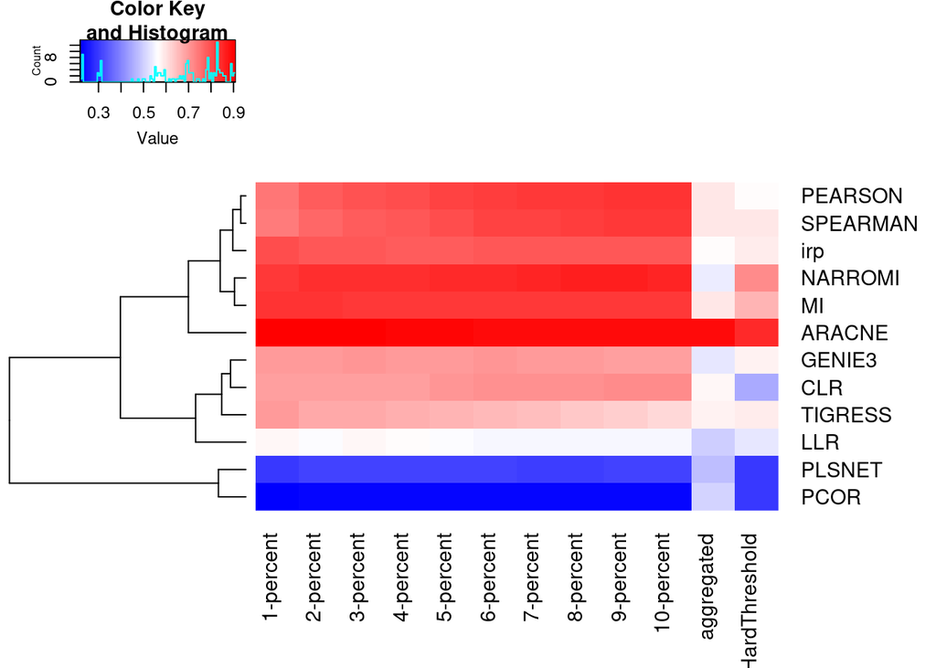

```r
heatmap.2(aucs,trace="none",col=hpal,margins=c(7.1,7.1),Colv=FALSE,dendrogram="row")
```

### 4.1.2 AUCs penalised by the number of Gold Standard (GS) edges used

The rationale here is to check the effect of a limited number of GS on the AUC calculation

```r
resb$aggregated=res
resb$hardthres=reshd

gsNum <- lapply(resb,select,c("ALGO","TP","FP")) %>%
  enframe %>% unnest(cols=c("value")) %>%
  mutate(TOTAL=TP+FP) %>% select(-c("TP","FP")) %>%
  pivot_wider(names_from=name,values_from=TOTAL) %>%
  column_to_rownames("ALGO") %>% as.matrix()

paucs <- aucs * t(t(gsNum) / colMaxs(gsNum))

pander(paucs)
```

Table continues below

|  | 1-percent | 2-percent | 3-percent | 4-percent | 5-percent |
| --- | --- | --- | --- | --- | --- |
| **ARACNE** | 0.4512 | 0.3695 | 0.3118 | 0.2672 | 0.2302 |
| **CLR** | 0.6928 | 0.6914 | 0.6933 | 0.6939 | 0.7015 |
| **GENIE3** | 0.5856 | 0.6018 | 0.6117 | 0.6124 | 0.6169 |
| **LLR** | 0.1077 | 0.1133 | 0.1212 | 0.1236 | 0.1266 |
| **MI** | 0.8353 | 0.8332 | 0.83 | 0.8264 | 0.8274 |
| **NARROMI** | 0.2105 | 0.2102 | 0.2084 | 0.2051 | 0.2043 |
| **PCOR** | 0.2188 | 0.2263 | 0.2304 | 0.2309 | 0.2302 |
| **PEARSON** | 0.7481 | 0.7827 | 0.7967 | 0.8031 | 0.8135 |
| **PLSNET** | 0.2936 | 0.3048 | 0.3088 | 0.3088 | 0.3067 |
| **SPEARMAN** | 0.7376 | 0.767 | 0.7817 | 0.7873 | 0.7998 |
| **TIGRESS** | 0.504 | 0.5166 | 0.5284 | 0.5333 | 0.5389 |
| **irp** | 0.7983 | 0.7867 | 0.7852 | 0.7786 | 0.7808 |

Table continues below

|  | 6-percent | 7-percent | 8-percent | 9-percent | 10-percent |
| --- | --- | --- | --- | --- | --- |
| **ARACNE** | 0.2008 | 0.1791 | 0.1578 | 0.1383 | 0.1224 |
| **CLR** | 0.7078 | 0.7101 | 0.7134 | 0.715 | 0.717 |
| **GENIE3** | 0.6195 | 0.6189 | 0.6192 | 0.6157 | 0.6145 |
| **LLR** | 0.1285 | 0.1316 | 0.1349 | 0.1387 | 0.1419 |
| **MI** | 0.8294 | 0.8291 | 0.8296 | 0.8279 | 0.8267 |
| **NARROMI** | 0.2035 | 0.2031 | 0.2028 | 0.2015 | 0.2001 |
| **PCOR** | 0.2293 | 0.2298 | 0.2294 | 0.2317 | 0.2319 |
| **PEARSON** | 0.8221 | 0.8268 | 0.8312 | 0.8341 | 0.8368 |
| **PLSNET** | 0.3058 | 0.304 | 0.3044 | 0.3074 | 0.3064 |
| **SPEARMAN** | 0.8114 | 0.8178 | 0.823 | 0.8266 | 0.8304 |
| **TIGRESS** | 0.5405 | 0.5402 | 0.5363 | 0.5313 | 0.5243 |
| **irp** | 0.7846 | 0.7863 | 0.788 | 0.7885 | 0.789 |

|  | aggregated | HardThreshold |
| --- | --- | --- |
| **ARACNE** | 0.0005144 | 0.4633 |
| **CLR** | 0.2696 | 0.4519 |
| **GENIE3** | 0.2651 | 0.5082 |
| **LLR** | 0.1874 | 0.2464 |
| **MI** | 0.5933 | 0.6654 |
| **NARROMI** | 0.4748 | 0.2482 |
| **PCOR** | 0.5014 | 0.3007 |
| **PEARSON** | 0.5935 | 0.5646 |
| **PLSNET** | 0.4778 | 0.2971 |
| **SPEARMAN** | 0.5908 | 0.594 |
| **TIGRESS** | 0.09312 | 0.4902 |
| **irp** | 0.5695 | 0.5905 |

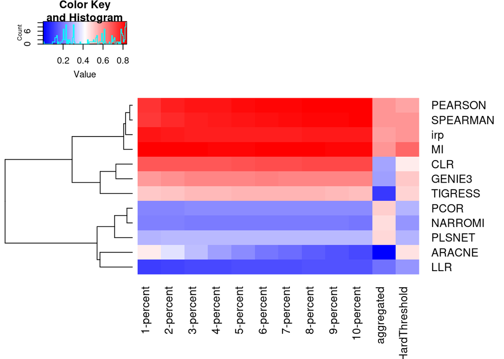

```r
heatmap.2(paucs,trace="none",col=hpal,margins=c(7.1,7.1),Colv=FALSE,dendrogram="row")
```

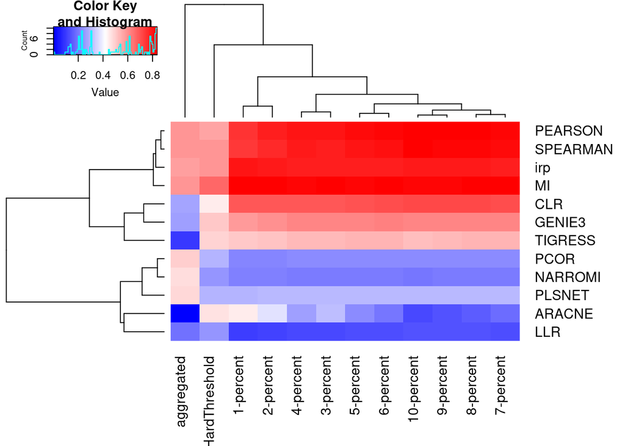

```r
heatmap.2(paucs,trace="none",col=hpal,margins=c(7.1,7.1))
```

# 5 Conclusion

WIthNegative we would use 9 or 5. With no negative they all look very similar so we would go with 1, which is less stringent